# ASICS User’s Guide

Gaëlle Lefort, Rémi Servien and Nathalie Vialaneix

2020-11-23

This user’s guide provides an overview of the package `ASICS`. `ASICS` is a fully automated procedure to identify and quantify metabolites in $^1$H 1D-NMR spectra of biological mixtures (Tardivel *et al.*, 2017). It will enable empowering NMR-based metabolomics by quickly and accurately helping experts to obtain metabolic profiles. In addition to the quantification method, several functions allowing spectrum preprocessing or statistical analyses of quantified metabolites are available.

```r
library(ASICS)
library(ASICSdata)
```

# 1 Dataset

In this user’s guide, a subset of the public datasets from Salek *et al.* (2007) is used. The experiment has been designed to improve the understanding of early stage of type 2 diabetes mellitus (T2DM) development. In the dataset used, $^1$H-NMR human metabolome was obtained from 25 healthy volunteers and 25 T2DM patients. Raw 1D Bruker spectral data files were found in the MetaboLights database (https://www.ebi.ac.uk/metabolights/, study MTBLS1).

# 2 Parallel environment

For most time consumming functions, a parallel implementation is available for unix-like OS using the BiocParallel package of Bioconductor. The number of used cores is set with the option `ncores` of the corresponding functions (default to `1`, no parallel environment).

# 3 Library of pure NMR metabolite spectrum

An object of class `PureLibrary` with spectra of pure metabolites is required to perform the quantification. Such a reference library is provided in `ASICS` with 191 pure metabolite spectra. These spectra are metabolite spectra used as references for quantification: only metabolites that are present in the library object can be identified and quantified with `ASICS`.

The default library is automatically loaded at package start. Available metabolites are displayed with:

```r
head(getSampleName(pure_library), n = 8)
```

```
## [1] "1,3-Diaminopropane"   "Levoglucosan"         "1-Methylhydantoin"
## [4] "1-Methyl-L-Histidine" "QuinolinicAcid"       "2-AminoAdipicAcid"
## [7] "2-AminobutyricAcid"   "2-Deoxyadenosine"
```

This library can be complemented or another library can be created with new spectra of pure metabolites. These spectra are imported from Bruker files and a new library can be created with:

```r
pure_spectra <- importSpectraBruker(system.file("extdata", "example_library",
                                                package = "ASICS"))
new_pure_library <- createPureLibrary(pure_spectra,
                                        nb.protons = c(5, 4))
```

A new library can also be created from txt or csv files, with samples in columns and chemical shifts in rows (see help page of `createPureLibrary` function for all details).

The newly created library can be used for quantification or merged with another one:

```r
merged_pure_library <- c(pure_library[1:10], new_pure_library)
```

The `PureLibrary` `merged_pure_library` contains the first ten spectra of the default library and the two newly imported spectra.

# 4 Identification and quantification of metabolites with ASICS

First, data are imported in a data frame from Bruker files with the `importSpectraBruker` function. These spectra are baseline corrected (Wang *et al*, 2013) and normalised by the area under the curve.

```r
spectra_data <- importSpectraBruker(system.file("extdata",
                                                "Human_diabetes_example",
                                                package = "ASICSdata"))
```

Data can also be imported from other file types with `importSpectra` function. The only constraint is to have a data frame with spectra in columns (column names are sample names) and chemical shifts in rows (row names correspond to the ppm grid).

```r
diabetes <- system.file("extdata", package = "ASICSdata")
spectra_data_txt <- importSpectra(name.dir = diabetes,
                                  name.file = "spectra_diabetes_example.txt",
                                  type = "txt")
```

Several functions for the preprocessing of spectra are also available: normalisation and alignment on a reference spectrum (based on Vu et al. (2011)).

Many types of normalisation are available. By default, spectra are normalised to a constant sum (`type.norm = "CS"`). Otherwise, a normalisation method implemented in the `PepsNMR` package could be used. For example:

```r
spectra_norm <- normaliseSpectra(spectra_data_txt, type.norm = "pqn")
```

```
## Normalisation method : pqn
```

The alignment algorithm is based on Vu et al. (2011). To find the reference spectrum, the FFT cross-correlation is used. Then the alignment is performed using the FFT cross-correlation and a hierarchical classification.

```r
spectra_align <- alignSpectra(spectra_norm)
```

Finally, from the data frame, a `Spectra` object is created. This is a required step for the quantification.

```r
spectra_obj <- createSpectra(spectra_align)
```

Recently, new methods for reference library alignment and metabolite quantification were added. Thus, multiple scenarios can be performed:

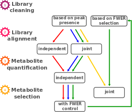

The method provided in the first version of the package is given in red. It can now be used by setting `joint.align = FALSE` and `quantif.method = "FWER"`. To perform a joint alignment (blue, green and yellow scenarios), `joint.align` needs to be set to `TRUE`. The yellow scenario that performs joint quantification based on a simple joint alignment is obtained by additionally setting `quantif.method = "Lasso"`. Finally, the green scenario performs a joint quantification using metabolites identified with a first step consisting of independent quantification. It is obtained by setting `quantif.method = "both"`.

With `quantif.method = "both"`, the number of identified metabolites can be controlled using `clean.thres`. If `clean.thres = 10`, only the metabolites identified in at least 10% of the complex spectra (during the first independant quantification step) are used in the joint quantification.

More details on these new algorithms can be found in Lefort *et al.* (2020).

`ASICS` function takes approximately 2 minutes per spectrum to run. To control randomness in the algorithm (used in the estimation of the significativity of a given metabolite concentration), the `set.seed` parameter can be used.

```r
# part of the spectrum to exclude (water and urea)
to_exclude <- matrix(c(4.5, 5.1, 5.5, 6.5), ncol = 2, byrow = TRUE)
ASICS_results <- ASICS(spectra_obj, exclusion.areas = to_exclude)
```

Summary of ASICS results:

```r
ASICS_results
```

```
## An object of class ASICSResults
## It contains 50 spectra of 31087 points.
##
## ASICS results:
##  162 metabolites are identified for this set of spectra.
## Most concentrated metabolites are: Creatinine, Citrate, AceticAcid, L-GlutamicAcid, L-Glycine, L-Proline
```

The quality of the results can be assessed by stacking the original and the reconstructed spectra on one plot. A pure metabolite spectrum can also be added for visual comparison. For example, the first spectrum with Creatinine:

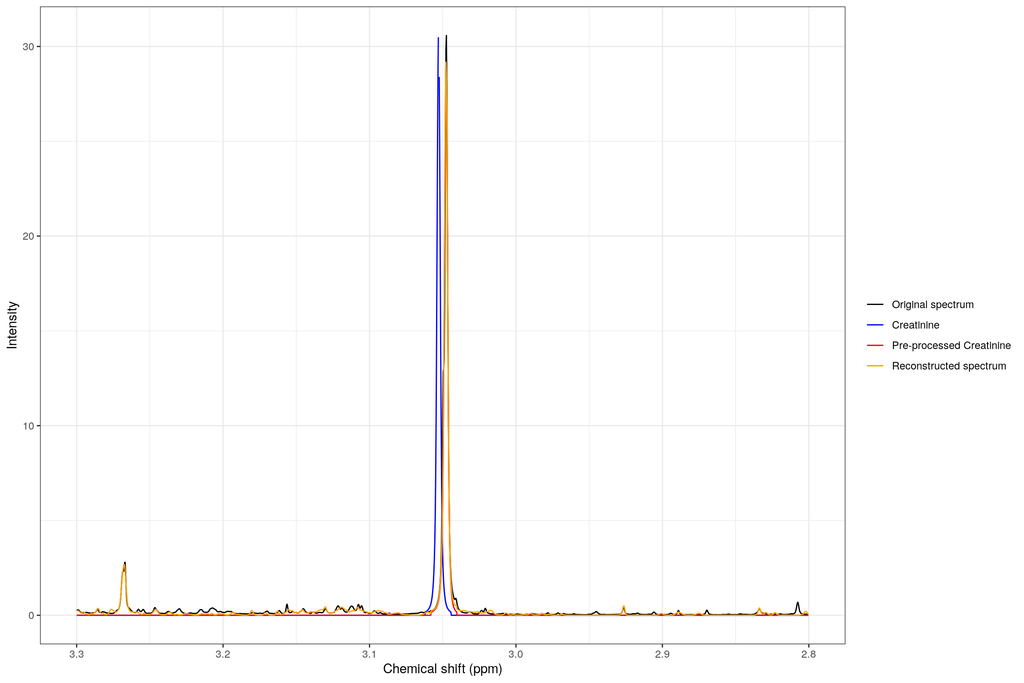

```r
plot(ASICS_results, idx = 1, xlim = c(2.8, 3.3), add.metab = "Creatinine")
```

Relative concentrations of identified metabolites are saved in a data frame accessible via the `get_quantification` function:

```r
head(getQuantification(ASICS_results), 10)[, 1:2]
```

```
##                   ADG10003u_007 ADG10003u_008
## Creatinine          0.027524645   0.016992328
## Citrate             0.009818148   0.003665571
## AceticAcid          0.004454905   0.000000000
## L-GlutamicAcid      0.002655211   0.001562384
## L-Glycine           0.002147344   0.002070631
## L-Proline           0.001960824   0.003139267
## 2-AminoAdipicAcid   0.001943956   0.001038924
## D-Mannose           0.001916896   0.002843512
## L-Aspartate         0.001868333   0.004047524
## ThreonicAcid        0.001803600   0.000000000
```

# 5 Analysis on relative quantifications

Some analysis functions are also available in `ASICS`.

First, a design data frame is imported. In this data frame, the first column needs to correspond to sample names of all spectra.

```r
design <- read.table(system.file("extdata", "design_diabete_example.txt",
                                 package = "ASICSdata"), header = TRUE)
```

Then, a preprocessing is performed on relative quantifications: metabolites with more than 75% of null quantifications are removed as well as two samples that are considered as outliers.

```r
analysis_data <- formatForAnalysis(getQuantification(ASICS_results),
                                   design = design, zero.threshold = 75,
                                   zero.group = "condition",
                                   outliers = c("ADG10003u_007",
                                                "ADG19007u_163"))
```

To explore results of ASICS quantification, a PCA can be performed on results of preprocessing with:

```r
resPCA <- pca(analysis_data)
```

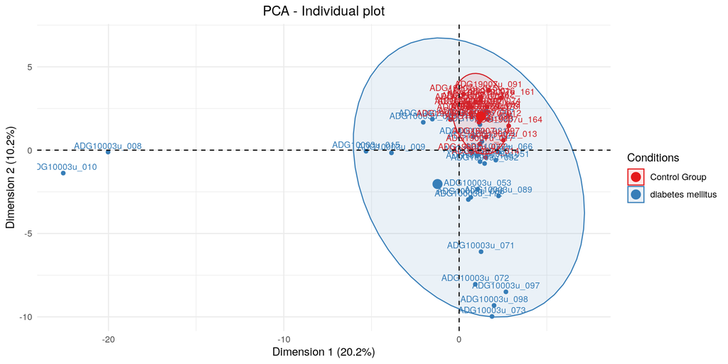

```r
plot(resPCA, graph = "ind", col.ind = "condition")
```

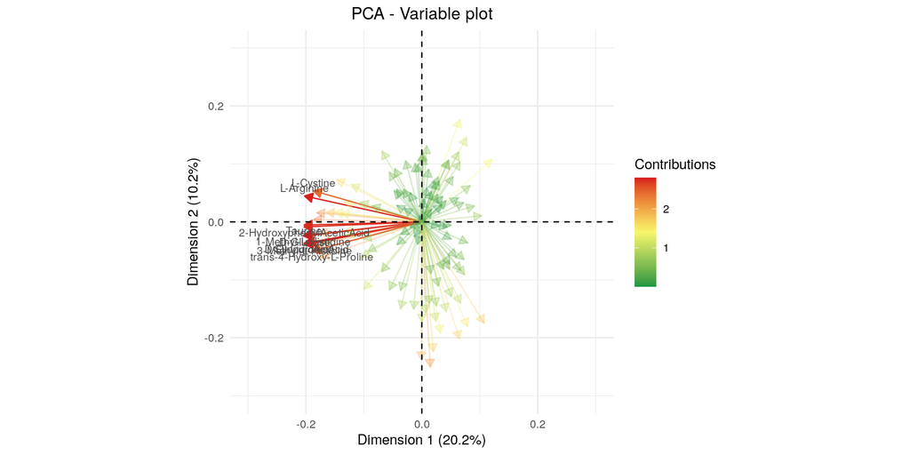

```r
plot(resPCA, graph = "var")
```

It is also possible to find differences between two conditions with an OPLS-DA (Thevenot *et al*, 2015) or with Kruskall-Wallis tests:

```r
resOPLSDA <- oplsda(analysis_data, condition = "condition", orthoI = 1)
resOPLSDA
```

```
## OPLS-DA performed on quantifications
## Cross validation error: 0.12
##
## Variable with the higher VIP:
##                       Control Group diabetes mellitus      VIP influential
## L-Citrulline           1.577558e-03      6.348160e-04 2.293155        TRUE
## Galactitol             1.062704e-03      2.947166e-04 2.259247        TRUE
## D-Glucose-6-Phosphate  1.718698e-03      2.042602e-03 2.046632        TRUE
## Trimethylamine         0.000000e+00      3.390938e-05 1.885807        TRUE
## Uracil                 1.290575e-03      4.742019e-04 1.862658        TRUE
## 3-PhenylPropionicAcid  6.515734e-04      8.718475e-04 1.818105        TRUE
## D-GluconicAcid         7.105618e-04      1.667304e-03 1.797962        TRUE
## 2-Oxobutyrate          4.440598e-05      5.164097e-04 1.754901        TRUE
## UrocanicAcid           1.578936e-05      1.932797e-04 1.713738        TRUE
## Levoglucosan           7.772079e-04      3.861891e-04 1.683468        TRUE
## [...]
```

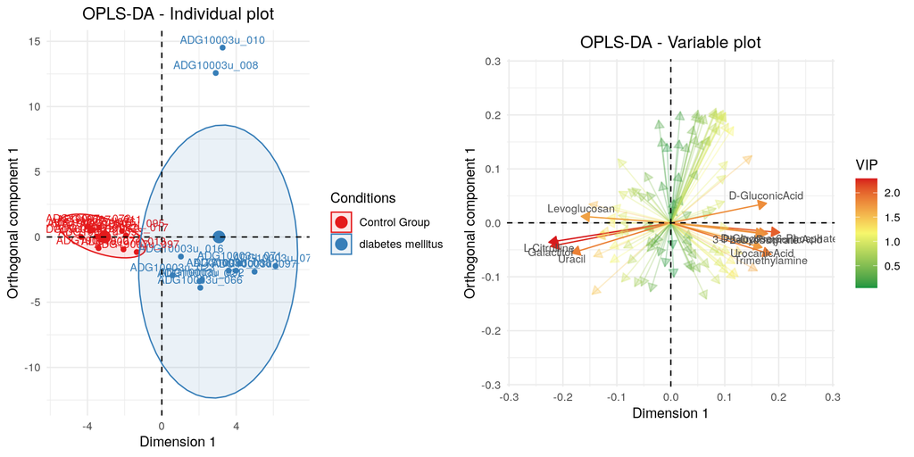

```r
plot(resOPLSDA)
```

Results of Kruskall-Wallis tests and Benjamini-Hochberg correction:

```r
resTests <- kruskalWallis(analysis_data, "condition")
resTests
```

```
## Kruskal-Wallis tests performed on quantifications
## Variable with the lower adjusted p-value:
##
##                  Feature Adjusted.p.value
## 1           L-Citrulline     9.789748e-05
## 2             Galactitol     2.703854e-04
## 3               Glycerol     3.268214e-03
## 4           Ethanolamine     1.624328e-02
## 5                 Uracil     6.168396e-02
## 6  D-Glucose-6-Phosphate     6.568338e-02
## 7         D-GluconicAcid     9.634158e-02
## 8                Inosine     1.117938e-01
## 9           Trigonelline     1.148400e-01
## 10         2-Oxobutyrate     1.617243e-01
## [...]
```

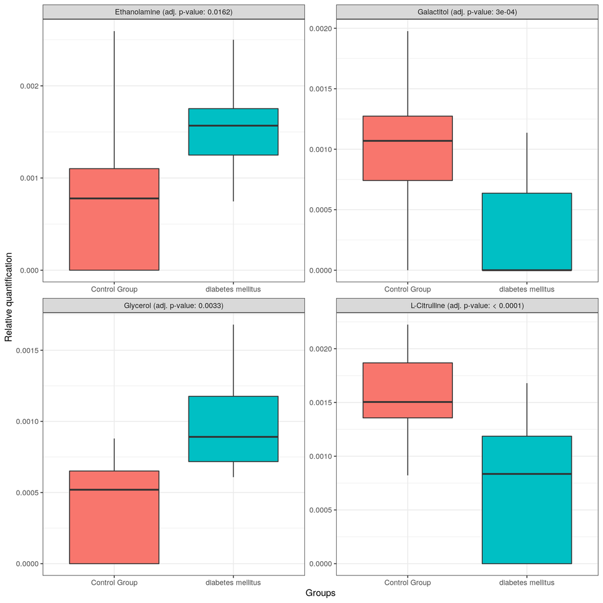

```r
plot(resTests)
```

# 6 Analysis on buckets

An analysis on buckets can also be performed. An alignment is required before the spectrum bucketing:

```r
spectra_align <- alignSpectra(spectra_norm)
spectra_bucket <- binning(spectra_align)
```

Alignment visualization:

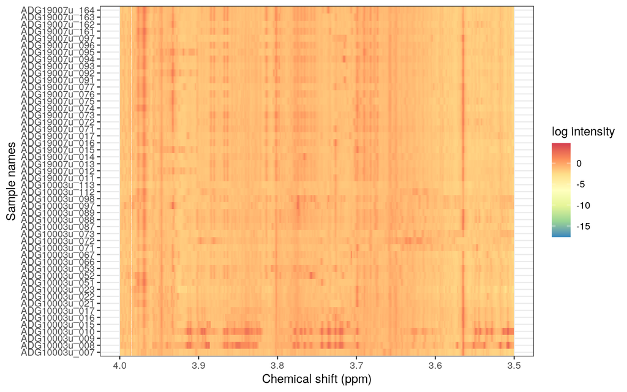

```r
spectra_obj_align <- createSpectra(spectra_align)

plotAlignment(spectra_obj, xlim = c(3.5,4))
```

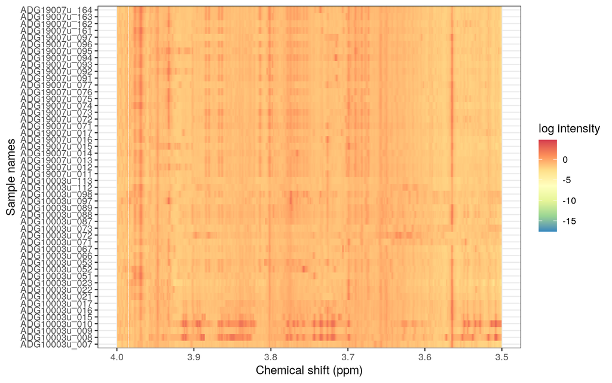

```r
plotAlignment(spectra_obj_align, xlim = c(3.5,4))
```

Then, a `SummarizedExperiment` object is created with the `formatForAnalysis` function as for quantification:

```r
analysis_data_bucket <- formatForAnalysis(spectra_bucket, design = design,
                                          zero.threshold = 75)
```

Finally, all analyses can be carried out on this object with the parameter `type.data` set to `buckets`. For example, the OPLS-DA is performed with:

```r
resOPLSDA_buckets <- oplsda(analysis_data_bucket, condition = "condition",
                            type.data = "buckets")
resOPLSDA_buckets
```

```
## OPLS-DA performed on buckets
## Cross validation error: 0.12
##
## Variable with the higher VIP:
##       Control Group diabetes mellitus      VIP influential
## 8.935 -1.133369e-05      3.615169e-07 2.240782        TRUE
## 4.115  1.014203e-03      1.317695e-03 2.164346        TRUE
## 3.785  4.080651e-03      4.902450e-03 2.144845        TRUE
## 8.625 -1.267405e-05      6.430714e-06 2.093072        TRUE
## 3.685  8.273601e-03      5.333275e-03 2.090887        TRUE
## 4.245  7.322459e-04      4.692211e-04 2.074871        TRUE
## 9.735 -8.501084e-06      2.194731e-06 2.063978        TRUE
## 6.335  1.075097e-05      3.006047e-05 2.036788        TRUE
## 5.255  2.055731e-04      3.849152e-04 2.032645        TRUE
## 8.635 -7.321572e-06      7.141929e-06 1.968756        TRUE
## [...]
```

Moreover, another plot with the median spectrum and OPLS-DA results can be produced with the option `graph = "buckets"`:

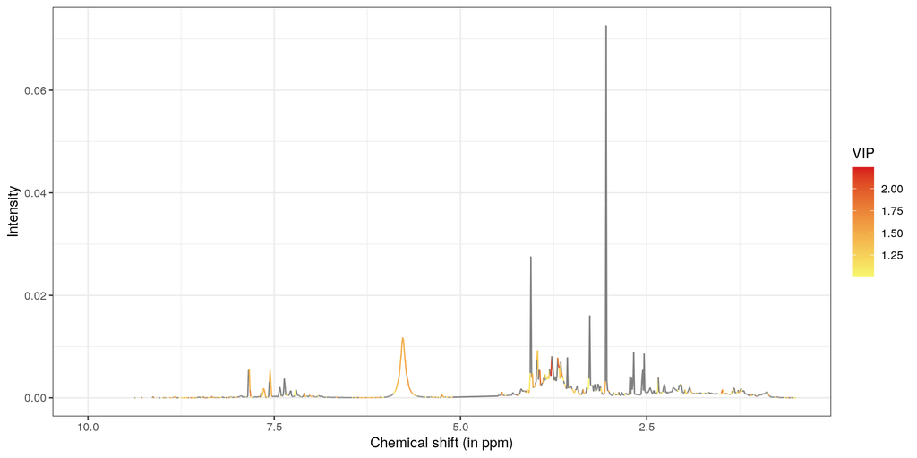

```r
plot(resOPLSDA_buckets, graph = "buckets")
```

# 7 References

Lefort G., Liaubet L., Marty-Gasset N., Canlet C., Vialaneix N., Servien R. . 2020. Pre-print, https://www.biorxiv.org/content/10.1101/2020.10.08.331090v1.

Tardivel P., Canlet C., Lefort G., Tremblay-Franco M., Debrauwer L., Concordet D., Servien R. (2017). ASICS: an automatic method for identification and quantification of metabolites in complex 1D 1H NMR spectra. *Metabolomics*, **13**(10), 109. https://doi.org/10.1007/s11306-017-1244-5

Salek, R. M., Maguire, M. L., Bentley, E., Rubtsov, D. V., Hough, T., Cheeseman, M., … & Connor, S. C. (2007). A metabolomic comparison of urinary changes in type 2 diabetes in mouse, rat, and human. *Physiological genomics*, **29**(2), 99-108.

Wang, K. C., Wang, S. Y., Kuo, C. H., Tseng, Y. J. (2013). Distribution-based classification method for baseline correction of metabolomic 1D proton nuclear magnetic resonance spectra. *Analytical Chemistry*, **85**(2), 1231–1239.

Vu, T. N., Valkenborg, D., Smets, K., Verwaest, K. A., Dommisse, R., Lemiere, F., … & Laukens, K. (2011). An integrated workflow for robust alignment and simplified quantitative analysis of NMR spectrometry data. *BMC bioinformatics*, **12**(1), 405.

Thevenot, E.A., Roux, A., Xu, Y., Ezan, E., Junot, C. 2015. Analysis of the human adult urinary metabolome variations with age, body mass index and gender by implementing a comprehensive workflow for univariate and OPLS statistical analyses. *Journal of Proteome Research*. **14**, 3322-3335.

# 8 Session information